# Random Forest Analysis

David Zeng

8/23/2021

# `my_rf_cv` Tutorial

This function uses the `my_penguins` data internally and trains a random forest model which predicts `body_mass_g` using covariates `bill_length_mm`, `bill_depth_mm`, and `flipper_length_mm`. It utilizes k-fold cross validation, so we will run our function using 2-fold, 5-fold, and 10-fold cross validation. We generate 30 iterations of a random forest model for each value of $k$.

```r
# load my_rf_cv function
source("../Code/my_rf_cv.R")
```

```r
# store results in a data frame
mse_df <- data.frame(matrix(nrow = 0, ncol = length(2)))
# run model on 2, 5, and 10 folds
for (folds in c(2, 5, 10)) {
  # generate model 30 times and store mse in a vector
  mse_vector <- rep(NA, 30)
  for (i in (1:30)) {
    avg_mse <- my_rf_cv(folds)
    mse_vector[i] <- avg_mse
  }
  # store results in aggregate data frame
  new_df <- data.frame(mse = mse_vector,
                       fold = rep(as.character(folds), 30))
  mse_df <- rbind(mse_df, new_df)
}
```

We generate boxplots of the data to visualize the distribution of the average mean squared error for each of the chosen number of folds.

```r
# create boxplot, 2-fold cv
plot_2cv <- ggplot2::ggplot(data = mse_df[1:30,], ggplot2::aes(x = fold, y = mse)) +
  ggplot2::labs(title = "Average Mean Squared Error, 30 Simulations",
                x = "Number of Folds",
                y = "Mean Squared Error") +
  ggplot2::geom_boxplot(fill = "lightblue") +
  ggplot2::theme_bw()

# create boxplot, 5-fold cv
plot_5cv <- ggplot2::ggplot(data = mse_df[31:60,], ggplot2::aes(x = fold, y = mse)) +
  ggplot2::labs(title = "Average Mean Squared Error, 30 Simulations",
                x = "Number of Folds",
                y = "Mean Squared Error") +
  ggplot2::geom_boxplot(fill = "lightblue") +
  ggplot2::theme_bw()

# create boxplot, 10-fold cv
plot_10cv <- ggplot2::ggplot(data = mse_df[61:90,], ggplot2::aes(x = fold, y = mse)) +
  ggplot2::labs(title = "Average Mean Squared Error, 30 Simulations",
                x = "Number of Folds",
                y = "Mean Squared Error") +
  ggplot2::geom_boxplot(fill = "lightblue") +
  ggplot2::theme_bw()
```

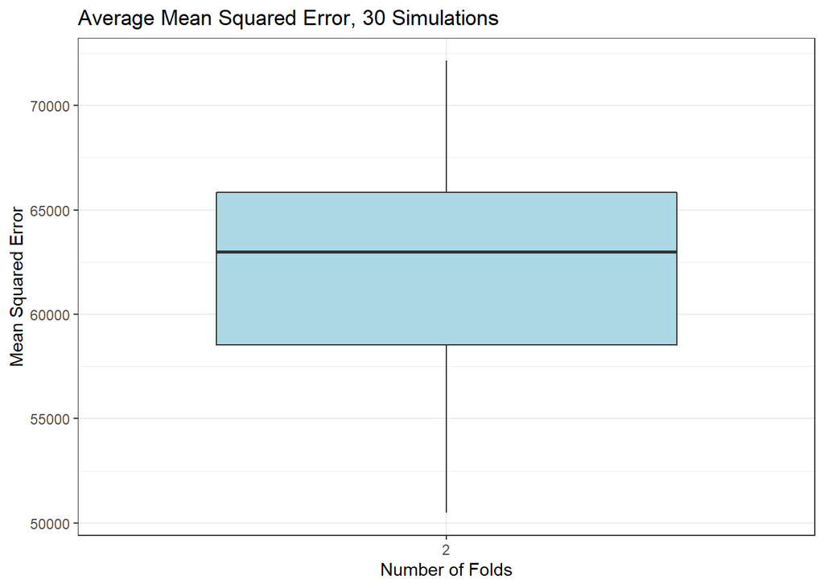

```r
# display boxplots
plot_2cv
```

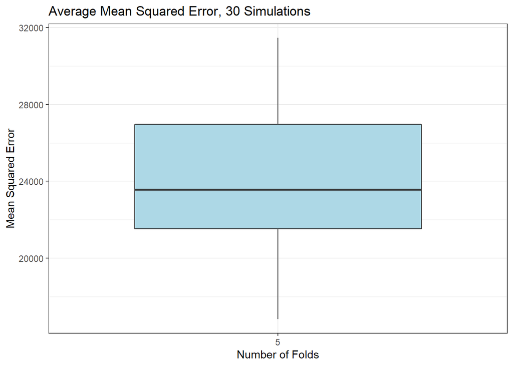

```r
plot_5cv
```

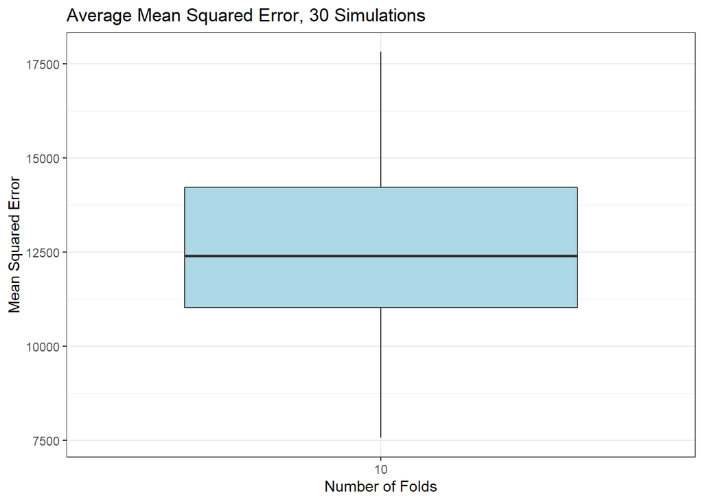

```r
plot_10cv
```

We can see that as the number of folds increases, the range of values for the average mean squared error decreases.

We also create a table which displays the average CV estimate and the standard deviation of the CV estimates for each number of folds used

```r
# create table of mean and standard deviation of MSE across each fold
avg_col <- rbind(mean(mse_df[1:30,1]), mean(mse_df[31:60,1]), mean(mse_df[61:90,1]))
sd_col <- rbind(sd(mse_df[1:30,1]), sd(mse_df[31:60,1]), sd(mse_df[61:90,1]))
results_table <- cbind(avg_col, sd_col)
rownames(results_table) <- c("2-fold CV", "5-fold CV", "10-fold CV")
colnames(results_table) <- c("Mean of MSE", "Standard Deviation of MSE")
results_table
```

```
##            Mean of MSE Standard Deviation of MSE
## 2-fold CV     62683.99                  5191.905
## 5-fold CV     23922.79                  3570.870
## 10-fold CV    12409.06                  2670.887
```

We can see that as the number of folds increases, the mean MSE decreases and the standard deviation of the MSE decreases. This is most likely due to the fact that as we increase the number of folds, we are increasing the size of our training set and decreasing the size of our test set, leading to more precise and accurate predictions.